# Solving conservation planning problems with integer linear programming (appendices)

HAWTHORNE L. BEYER (1,3), YANN DUJARDIN (2), MATT WATTS (1) & HUGH P. POSSINGHAM(1)

1 ARC Centre of Excellence for Environmental Decisions, Centre for Biodiversity & Conservation Science, University of Queensland, Brisbane QLD 4072, Australia  
2 CSIRO Ecosystem Sciences, Ecosciences Precinct, Dutton Park, QLD 4102, Australia  
3 Corresponding author email: hawthorne@spatialecology.com

Original publication:

Beyer, H. L., Dujardin, Y., Watts, M. E., & Possingham, H. P. (2016). Solving conservation planning problems with integer linear programming. Ecological Modelling, 328, 14–22. DOI: 10.1016/j.ecolmodel.2016.02.005

## A Summary

Section B provides a detailed case study of how to implement the Marxan with Zones (Watts et al., 2009) objective functions in an integer linear programming (ILP) framework using the linearisation techniques described in the main text.

Section C is a detailed description of implementing ILP optimisation problems using R and Gurobi, including documented code for the simulations reported in the main text.

## B Linearisation of the Marxan With Zones reserve selection optimisation problem

A variation on the Marxan problem in which each planning unit can take on more than two states is called ‘Marxan with Zones’ (Watts et al., 2009). This functionality allows several additional types of problems to be addressed depending on what the stratification of states represent (management actions, zoning types, etc). For example, Klein et al. (2010) use this approach to assign marine planning units to one of five zones that regulated the conservation status and level of fishing allowed, ranging from complete conservation protection to unrestricted commercial fishery.

MarxanWith Zones solves the following optimisation problem:

$$min \sum_{i=1}^{N} \sum_{k=1}^{Z} c_{ik}x_{ik} + \sum_{k=1}^{Z} \sum_{m=1}^{Z} b_{km} \sum_{i=1}^{N} \sum_{j=1}^{N} x_{ik}x_{jm}v_{ijkm}$$

$$s.t \sum_{k=1}^{Z} x_{ik} = 1, i \in N$$

$$\sum_{i=1}^{N} \sum_{k=1}^{Z} a_{ij}p_{jk}x_{ij} \geq T_{j},j \in N$$

$$\sum_{i=1}^{N} a_{ij}x_{ik} \geq U_{jk},j \in N,k \in K$$

$$x_{i} \in \{0,1\},i \in N$$

where $N$ and $Z$ refer to the number of planning units and zones (actions) respectively, $x_{ik}$ is a binary decision variable that is 1 when unit $i$ is assigned to zone $k$ and 0 otherwise. In the first part of the objective function $c_{ik}$ is the cost of planning unit $i$ when assigned to zone $k$. Thus, the costs associated with selecting a planning unit can vary among the different zone types and planning units. The second part of the objective function provides a way of enforcing or facilitating the assignment of zones between pairs of units (often neighbouring units). For example, conflicting zones in neighbouring units could be discouraged by assigning a higher penalty in the array $v$. It is also possible to specify $v$ to facilitate greater clumping of units of a given zone type by assigning a cost to same-type pairs that is less than the cost of any different-type pairs. Although $v$ is large (a four dimensional array), it may contain many zeros if costs are only assigned to neighbouring units, making it more straightforward to linearise this problem (because we can ignore any instances of $x_{ik}x_{jm}$ for which $v_{ijkm} = 0$). As with the Marxan objective function (Eqn 4), parameter matrix $b_{km}$ can be adjusted by the decision maker to control the overall strength of the penalties.

The first constraint ensures that each planning unit is assigned to exactly one zone. In the second constraint $a_{ij}$ represents the amount or value of feature $j$ in unit $i$ and $p_{jk}$ is the proportion of that feature that is preserved when the unit is assigned to zone $k$. Thus, summed over all planning units and zones, this constraint ensures that minimum representation targets ($T_{j}$) are met. The final constraint ensures that targets ($U$) for the amounts of feature $j$ are represented by specific zone types. For example, if the targets refer to species abundances, and the zones refer to multiple land use types, then this last constraint could be used to ensure that at least 50% of the abundance was represented by fully protected conservation areas.

As with Marxan, the constraints in the Marxan with Zones problem are incorporated into the objective function in the form of a shortfall penalty function (Watts et al., 2009) that allows solutions to be found even when all targets are not met. When all targets are met, however, the shortfall penalty is 0. For the purposes of implementing Marxan with Zones as an ILP problem we choose not to merge the constraints with the objective function as this allows for greater flexibility in customising the problem.

This constraint ensures that $z_{ijkm} = 1$ when $x_{ik} = x_{jm} = 1$, and that $z_{ij} = 0$ when either $x_{ik} = 0$ or $x_{jm} = 0$. Note that this constraint differs from the two constraints needed to linearise the Marxan objective function because the sign of the quadratic term differs. We can also express the objective function using set notation, which makes it clearer that the penalty term is only evaluated for neighbours:

$$min \sum_{i=1}^{N} \sum_{k=1}^{Z} c_{ik}x_{ik} + \sum_{k=1}^{Z} \sum_{m=1}^{Z} b_{km} \sum_{(i,j) \in E} x_{ik}x_{jm}v_{ijkm}$$

where $E$ defines the set of all neighbouring planning units.

A number of customisations of this problem are possible. It may be appropriate to allow no zone assignment to some units in cases where only a subset of unit and zone combinations are required to meet targets. This can be achieved by changing the first constraint to:

$$\sum_{k=1}^{Z} x_{ik} \leq 1,$$

thereby relaxing the constraint that forces all planning units to be assigned to exactly one zone.

Another problem is forcing some units to be assigned particular zones. Even though there is no ‘decision’ to be made for such units it is often necessary to include them in optimisation problems because they can affect zone assignments to other units via the second component of the optimisation function. For example, in a planning problem it may be unrealistic to transform urban areas into any other land use type, so they would be fixed as urban. But if a penalty has been implemented for placing protected areas adjacent to urban area these planning units would need to be included in the problem. Although it is possible to force zone assignments by assigning large costs to alternative zones in the cost matrix $c_{ik}$, a more direct and definitive approach is to implement a constraint $x_{ik} = 1$ for each $i_{k}$ corresponding to existing urban planning units. We note that such constraints can also be implemented in Marxan with Zones (see Watts et al., 2008).

Similarly, to prevent the assignment of incompatible zones in adjacent planning units (e.g. a dredge spoil dump next to a marine protected area) two constraints can be implemented:

$$x_{ik} + x_{jm} \leq 1, i \in N, j \in N$$
$$x_{im} + x_{jk} \leq 1, i \in N, j \in N$$

where $k$ and $m$ are the incompatible zones.

In Marxan With Zones these relationships will be enforced less explicitly by means of the values that are assigned to the cost matrix cik and the penalty array $v_{ijkm}$. Indeed, adding additional constraints to enforce these effects is detrimental to processing times as it increases the dimension size of the problem. The benefit of using the constraint approach, however, is that it is definitive. Finding suitable values for $c$ and $v$ to prevent undesirable solutions from arising often involves a process of trial and error, particularly when parameter $b$ is also being adjusted as this affects the penalties. The decision maker must inspect the solutions to determine whether undesirable assignments have occurred and this can be difficult to do effectively for very large problems. Implemented as a constraint, we are certain that these undesirable assignments are precluded, thereby removing the reliance on users to appropriately tune the problem formulation.

## C Implementation of linear programming methods to conservation planning

Here, we explain how to solve ILP problems using R and the commercial optimisation software Gurobi. This includes code for simulating 10,000 planning units with cost and species data for 10 species (Section 2), using this data to solve a simple, linear ILP reserve selection problem (Section 3), using this data to solve the non-linear Marxan objective function (Section 4), and some general advice for solving large ILP problems (Section 5). We recommend that readers understand how the simpler reserve selection problem is solved (Section 3) before moving on to the Marxan problem (Section 4), which is considerably more complex.

We note that copying and pasting code from a PDF format can sometimes cause issues with how quotation marks are translated into plain text. If you experience problems you may wish to first look at whether replacing the single and double quotation marks resolves the problem.

### C.1 Alternative linear programming software

Alternatives to Gurobi include the commercial software CPLEX (IBM, Inc., 2009), MatLab (MATLAB, 2014) and Mathematica (Mathematica, 2014), and the open source software lpSolve (Berkelaar et al., 2005). We have found that processing times with lpSolve can be considerably longer than Gurobi. Furthermore, the R interface to lpSolve (the `lpSolve` R package) lacks some important features, including the ability to accept constraint matrices in the sparse format and setting to determine when the solver exits (a time limit or gap statistic). Thus, only the smaller ILP problems we evaluate could be implemented though the lpSolve R interface and the more complex problems would have to be implemented through the lpSolve programming interface (the API) or possibly the command line interface. We do not explore this functionality here.

### C.2 Generating spatial datasets

The following R code was used to simulate input data for the case study, including 10 raster (matrix) datasets representing the value of each planning unit (one raster cell) to each of 10 species of conservation concern, and another raster representing the cost of selecting a planning unit for inclusion in the reserve system. To run this code it is necessary to first install the `RandomFields` library in R.

#### 1. Species data representing the value of each planning unit (raster cell)

to each species

```r
# user defined parameters:
# set the number of rows and columns of the raster:
nr <- 100 # rows
nc <- 100 # cols

# set the number of species:
ns <- 10 # species

# run the following code without modification:
N <- nr * nc
x <- seq(0, 100, length.out = nc)
y <- seq(0, 100, length.out = nr)

# the random field parameters are set here and can be adjusted
model <- "stable"
mean <- 0
variance <- 4
nugget <- 1
scale <- 20
alpha <- 1

# species array
spp <- array(0, dim = c(ns, nr, nc))
for (i in 1:ns) {
  f <- GaussRF(x = x, y = y, model = model, grid = TRUE,
               param = c(mean, variance, nugget, scale, alpha))
  f[which(f < 0)] <- 0
  spp[i,,] <- f
}

# save the species data as an R data object
# save(spp, file="spp.RData")
# the data can subsequently be reloaded using this command:
# load(file="spp.RData")
```

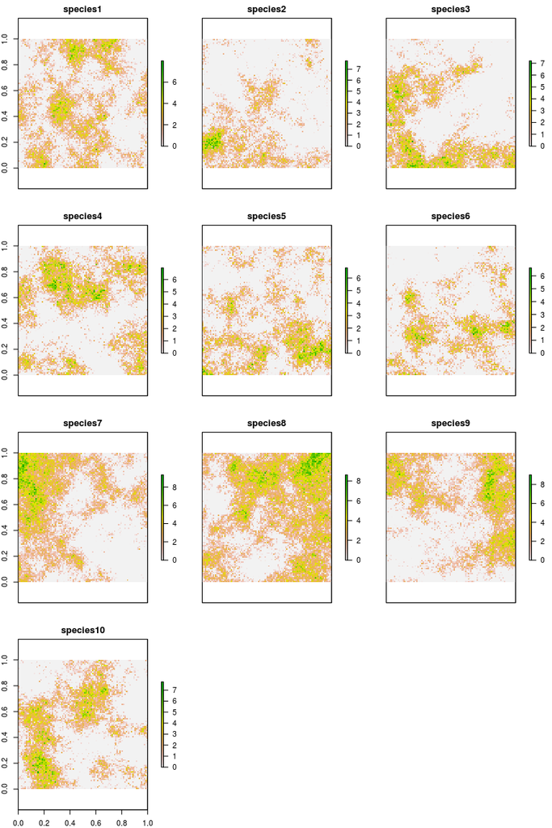

```r
# Make a RasterStack for plotting purposes
spps <- stack()

for (i in 1:ns) {
  spps <- addLayer(spps, raster(spp[i,,]))
}
names(spps) <- paste0("species", 1:ns)

plot(spps, nc = 3, nr = 4)
```

### 2. Simulate the cost associated with selecting each planning unit

```r
# reset the random field parameters (can be adjusted):
mean <- 1000
variance <- 100
nugget <- 1
scale <- 20
alpha <- 1.5
x <- seq(0, 100, length.out = nc)
y <- seq(0, 100, length.out = nr)

cost <- GaussRF(x = x, y = y, model = model, grid = TRUE,
                param = c(mean, variance, nugget, scale, alpha))
# save the species data as an R data object
# save(cost, file="cost.RData")
# the data can subsequently be reloaded using this command:
# load(file="cost.RData")
```

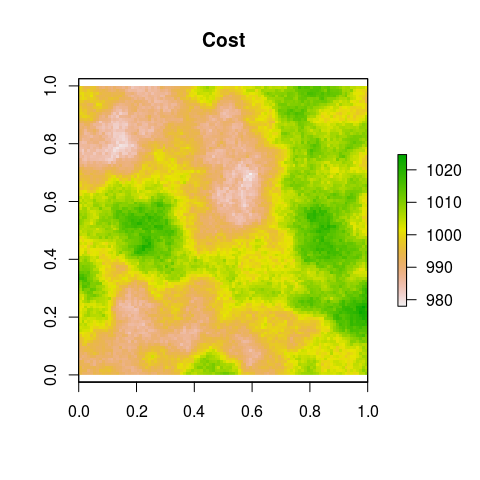

```r
plot(raster(cost), main = "Cost")
```

```r
# Create equal cost surface
cost_equal <- raster(matrix(rep(1, nr * nc), nrow = nr, ncol = nc))
```

## C.3 Solving the basic reserve selection problem using ILP

Here, we demonstrate how to solve the basic reserve selection problem (see Eqn 1 in the main text) using R and the commercial optimisation software Gurobi (Gurobi Optimization, Inc., 2014). This is largely simply a problem of data organisation so that the call to the Gurobi interface in R can be made (the `gurobi` function in the `gurobi` pacakge in R).

The costs (the values that are being minimised) must be represented in a vector in which each item corresponds to a decision variable. Decision variables are synonymous with planning units in problems that do not require linearisation. Thus, if there are 10,000 planning units, the cost vector will be of length 10,000 for linear problems. We address the more complex issue of non-linear problems below.

The constraints must be organised in a matrix in which the columns correspond to decision variables and the rows correspond to individual constraints. If there are 10,000 planning units and 15 constraints, the matrix will have dimensions 10,000 columns by 15 rows for linear problems. This matrix represents the left hand side of each constraint equation. Associated with the constraints matrix are two vectors representing the right hand side of each constraint equation (e.g. the target values) and the equality relationship for each constraint equation (<, >,≤,≥, or =). Thus the right hand side is a numerical vector and the equality relationship is a character vector, each with a length equal to the number of rows of the constraint matrix (15 in the example above).

Note that the order of values in the cost vector and the constrain matrix must match. I.e. the 10th item in the cost vector corresponds to a planning unit that must also refer to the planning unit in the 10th column of the constraints matrix. Often the hardest part of implementing ILP problems is ensuring that the order of planning units in these data objects is correct. Note the use of the transpose function, `t()`, in the code below to ensure that the order is correct when converting the spatial data (a 2D matrix) to a linear vector.

There are also a small number of other parameters that must be set. The `modelsense` parameter indicates whether the function should be minimised or maximised (`min` or `max` respectively). The `vtype` parameter is used to indicate that the decision variables are binary (`B`). Finally, a parameter vector can be specified with a range of options that control the algorithm, such as indicating when the algorithm should force termination, or the gap that should be achieved before termination (details of these settings are available in the Gurobi documentation).

This example assumes that the relevant spatial datasets have been loaded in R (see the previous section).

```r
# load the gurobi R package (requires that both Gurobi and the Gurobi R package
# have both been installed):
require(gurobi)
# re-specify the number of rows and columns of the raster if they are not
# already set in R:
nr <- 100 # rows
nc <- 100 # cols
# re-specify the number of species:
ns <- 10 # species
# run the following code without modification:
N <- nr * nc

# solve the basic reserve selection problem
# create the constraint matrix with appropriate dimensions
constr <- matrix(0, nrow = ns, ncol = N)

# in our example we have one contraint for each of 10 species so we populate the
# matrix from our species rasters:
for (i in 1:ns) {
  constr[i,] <- as.vector(t(spp[i,,]))
}

# create a vector of default equalities (these can be adjusted later, though we
# do not need to adjust them in this example):
sense <- rep(">=", ns)

# set the targets (the right hand side of the constraint equations); here, we
# assume that 25% of the total value of each species raster must be met or
# exceeded:
targetlevel <- 0.05
rhs <- rep(0, ns)
for (i in 1:ns) {
  rhs[i] <- targetlevel * sum(spp[i,,])
}

# set up Gurobi model object in R
model <- list()

# set this as a minimisation problem:
model$modelsense <- "min"
# set all decision variables as binary:
model$vtype <- "B"
# vector of state values that are being minimised (costs in our example):
model$obj <- as.vector(t(cost_equal))
# assign the constraints matrix object, and the right hand side and sense vectors:
model$A <- constr
model$rhs <- rhs
model$sense <- sense
# set the parameters that control the algorithm (the algorithm stops when a gap
# of 0.5% is achieved in this example):
params <- list(Presolve = 2, MIPGap = 0.005)
# solve the problem
result <- gurobi(model,params)
```

The result object contains several data objects including the objective value achieved (`result$objval` = 262) and the vector of decision variable values (0 or 1 in our example because the variables are binary).

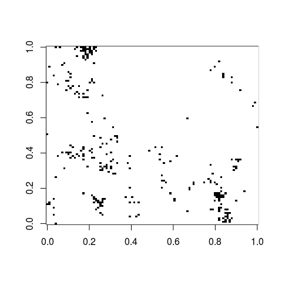

```r
reserve_network <- matrix(result$x, ncol = nc, nrow = nr)
image(reserve_network, col = c("white", "black"))
```

## C.4 Solving the Marxan optimisation problem using ILP

Here, we demonstrate how to solve the basic reserve selection problem (see Eqn 4 in the main text) using R and the commercial optimisation software Gurobi (Gurobi Optimization, Inc., 2014). As with the simple reserve selection problem this is largely simply a problem of data organisation. What makes it more complicated, however, is that the objective function must be linearised thereby adding new decision variables. As discussed in the main text, numerous additional decision variables are sometimes needed to linearise a non-linear objective function.

The data structures needed are similar to those described in the previous section. One difference is that the dimensions of the cost vector and the constraint matrix will increase as new decision variables are added. As the additional decision variables associated with each linearisation term only affect two planning units at a time, one consequence of linearisation is that the constraint matrix becomes both sparse and large. As such, it is no longer desirable to express the constraint matrix in its full format as this could consume a great deal of memory (RAM) even for modestly sized problems. Instead, we use the sparse matrix format.

Another important difference is that a new data structure is needed to describe the neighbour-relationships. In our example we look at the 4 cardinal neighbours for each planning unit (though units on the edge of the raster have less than 4 neighbours, and this too must be accounted for). There are numerous ways such data structures could be implemented. In the case of a regular grid of planning units with a fairly consistent number of neighbours we implement the data structures as a matrix. In the case of polygons with an irregular number of neighbours it would be better to implement this data structure as a list. Thus, some adaptation of this code may be needed to apply it to other problems.

### C.4.1 Create data structure defining neighbours

Here, we assume that the planning units are numbered sequentially beginning from 1. A value of 0 indicated NoData for planning units at the edge of the raster with fewer than 4 neighbours. The following code assigns the neighbour ID numbers, which is straightforward to calculate arithmetically for a grid of planning units. If the planning units were irregular polygons then determining neighbours would require the use of GIS functions.

```r
# create the planning unit (PU) neighbour matrix
neighbours <- matrix(0, nrow = N, ncol = 4)
# all middle PUs have 4 neighbours:
for (i in 2:(nc - 1)) {
  for (j in 2:(nr - 1)) {
    id <- (j - 1) * nc + i
    neighbours[id, 1] <- id - nc
    neighbours[id, 2] <- id + nc
    neighbours[id, 3] <- id - 1
    neighbours[id, 4] <- id + 1
  }
}

# first and last row, excluding corners
for (i in 2:(nc - 1)) {
  id <- i
  neighbours[id, 1] <- id + nc
  neighbours[id, 2] <- id - 1
  neighbours[id, 3] <- id + 1
  id <- (nr - 1) * nc + i
  neighbours[id, 1] <- id - nc
  neighbours[id, 2] <- id - 1
  neighbours[id, 3] <- id + 1
}

# first and last columns, excluding corners
for (i in 2:(nr - 1)) {
  id <- (i - 1) * nc + 1
  neighbours[id, 1] <- id + nc
  neighbours[id, 2] <- id - nc
  neighbours[id, 3] <- id + 1
  id <- i * nc
  neighbours[id, 1] <- id + nc
  neighbours[id, 2] <- id - nc
  neighbours[id, 3] <- id - 1
}

# corners
id <- 1
neighbours[id, 1] <- id + nc
neighbours[id, 2] <- id + 1
id <- nc
neighbours[id, 1] <- id + nc
neighbours[id, 2] <- id - 1
id <- nc * (nr - 1) + 1
neighbours[id, 1] <- id - nc
neighbours[id, 2] <- id + 1
id <- nc * nr
neighbours[id, 1] <- id - nc
neighbours[id, 2] <- id - 1
```

### C.4.2 Solve the linearised Marxan objective function

In this example the number of decision variables will be one for each planning unit plus one for each pair of neighbours as we assume a symmetric cost for not selecting each pair of neighbours (the cost for not selecting $A$ if $B$ is selected is the same as the cost for not selecting $B$ if $A$ is selected). In the case of asymmetric costs, twice as many additional decision variables would be required to linearise the objective function.

We also assume an arbitrary ‘cost’ of b units for failing to select neighbouring planning units. This value has no significance in our example other than to control the degree of aggregation of planning units, and is subjectively adjusted by the decision maker. Specifically we assume here that $\sf{v_{if}} = 1$ for all neighbours, $\sf{v_{ij}} = 0$ for all non-neighbours, and $b$ is adjusted by the decision maker (see Eqn 4 in the main text). If real costs have been estimated they could certainly be used here, including different values for each pair of planning ($\sf{v_{ij}} = 0$) units if that data is available.

```r
# load the gurobi R package (requires that both Gurobi and the Gurobi R package
# have both been installed):
require(gurobi)
# load the Matrix package for sparse matrices
require(Matrix)
# re-specify the number of rows and columns of the raster if they are not
# already set in R:
nr <- 100 # rows
nc <- 100 # cols
# re-specify the number of species:
ns <- 10 # species
# run the following code without modification:
N <- nr*nc

# set a default penalty factor here:
b <- 50

# determine the number of additional decision variables (M) required:
M <- length(which(neighbours > 0))
# construct the cost vector from the cost raster and with an additional M
# replicates of b for the additional decision variables:
objvals <- c(as.vector(t(cost)), rep(b, M))

# to construct the sparse constraints matrix we need three empty vectors that
# are subsequently populated; it is often difficult to calculate the required
# size a priori, so we create large vectors and adjust their size later;
# # mc, mr and mz refer to the column position, row position and value of each
# cell in the constraint matrix:
mc <- rep(0, 1000000)
mr <- rep(0, 1000000)
mz <- rep(0, 1000000)

# similarly, we create large vectors for the equality relationship and right
# hand side values, and adjust their length later; we set the default sense
# to <= so that we do not have to specify it in the iterative loop later:
sense <- rep("<=", 100000)
rhs <- rep(0, 100000)

# the first 10 rows of the constraint matrix correspond to the species targets,
# which we populate as follows:
mc[1:(N * ns)] <- rep(c(1:N), ns)
mr[1:(N*ns)] <- rep(c(1:ns), each = N)
for (i in 1:ns) {
  pos <- (i - 1) * N + 1
  mz[pos:(pos + N - 1)] <- as.vector(t(spp[i,,]))
}
# we need to adjust the sense matrix for these species targets:
sense[1:ns] <- ">="
# we populate the right hand side values as we did in the previous section:
# set the targets (the right hand side of the constraint equations); here, we
# assume that 25% of the total value of each species raster must be met or
# exceeded:
targetlevel <- 0.25
target <- rep(0, ns)
for (i in 1:ns) {
  target[i] <- targetlevel * sum(spp[i,,])
}
rhs[1:ns] <- target

# now work through all the neighbours, adding two constraints for each one we
# use cr to indicate the current row of the constraint matrix, idx refers to the
# current index of the mc, mr and mz vectors, and z refers to the index of the
# new decision variable (column).
z <- N + 1
idx <- N * ns + 1
cr <- ns + 1

for (i in 1:N) {
  ids <- neighbours[i, which(neighbours[i,] > 0)]
  for (j in 1:length(ids)) {
    # z_ij - x_i <= 0
    mc[idx] <- i
    mr[idx] <- cr
    mz[idx] <- -1
    idx <- idx + 1
    mc[idx] <- z
    mr[idx] <- cr
    mz[idx] <- 1
    idx <- idx + 1
    cr <- cr + 1

    # z_ij - x_j <= 0
    mc[idx] <- ids[j]
    mr[idx] <- cr
    mz[idx] <- -1
    idx <- idx + 1
    mc[idx] <- z
    mr[idx] <- cr
    mz[idx] <- 1
    idx <- idx + 1
    cr <- cr + 1

    z <- z + 1
  }
}

# finally, resize the vectors to the right size:
idx <- idx - 1
mc <- mc[1:idx]
mr <- mr[1:idx]
mz <- mz[1:idx]
cr <- cr - 1
sense <- sense[1:cr]
rhs <- rhs[1:cr]

# construct the sparse matrix:
constr <- sparseMatrix(i = mr, j = mc, x = mz)

# set up Gurobi model object in R
model <- list()
# set this as a minimisation problem:
model$modelsense <- "min"
# set all decision variables as binary:
model$vtype <- "B"
# vector of state values that are being minimised (costs in our example):
model$obj <- objvals
# assign the constraints matrix object, and the right hand side and sense
# vectors:
model$A <- constr
model$rhs <- rhs
model$sense <- sense
# set the parameters that control the algorithm (the algorithm stops when a gap
# of 0.5% is achieved in this example):
params <- list(Presolve = 2,MIPGap = 0.005)
# solve the problem
result <- gurobi(model, params)
```

The result object contains several data objects including the objective value achieved (`result$objval`) and the vector of decision variable values (0 or 1 in our example because the variables are binary).

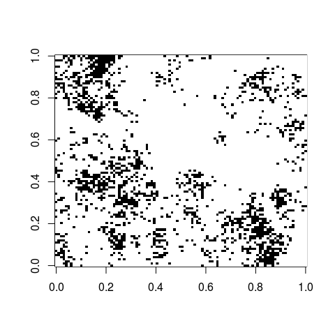

```r
reserve_network <- matrix(result$x, ncol = nc, nrow = nr)
image(reserve_network, col = c("white", "black"))
```

### C.4.3 Calculating the Pareto frontier

Once the basic data structures have been established the Pareto frontier can be estimated by iteratively solving the optimisation problem for different values of the penalty factor $b$. In our example that simply involves adjusting the cost vector. Determining the range of penalty values to explore, and the interval between them requires trial and error.

```r
# create a vector of penalty values to use:
pen <- seq(0, 175, 25)
#pen <- seq(0, 50, 25)
# create some empty data objects to store the objective values and solutions for
# visualisation:
sols <- list()
solcost <- rep(0, length(pen))

# loop through the penalties, optimising for each one:
for (p in 1:length(pen)) {
  objvals <- c(as.vector(t(cost)), -rep(pen[p], M))
  model$obj <- objvals
  result <- gurobi(model, params)
  sols[[p]] <- result$x
  solcost[p] <- result$objval
  save(sols, file = "sols.RData")
  save(solcost, file="solcost.RData")
}
```

Note that the above code saves the sols and solcost results objects within the loop. This is precautionary. For some problems the optimisation can take a considerable amount of time to run and if the objects are not saved regularly they could be lost if there is a problem with the computer.

```r
# Make a RasterStack for plotting purposes
solutions <- stack()

sols_mtrxs <- list()

for (i in 1:length(sols)) {
  sols_mtrxs[[i]] <- matrix(sols[[i]], ncol = nc, nrow = nr)
}

for (i in 1:length(sols)) {
  solutions <- addLayer(solutions, raster(sols_mtrxs[[i]]))
}
solutions <- addLayer(solutions, raster(cost))
names(solutions) <- c(paste0("solution", 1:length(sols)), "cost")

plot(solutions, nc = 3, nr = 3)
plot(pen, solcost, type="l", xlab="Penalty", ylab="Solution cost")
```

[output not shown]